# Podstawowe funkcje Jupyter Notebooka

Jupyter Notebook pozwala tworzyć dokumenty, które łączą ze soba:

- sformatowany tekst i ilustracje
- kod źródłowy
- wyniki wykonywania kodu

Dzięki tym funkcjom możemy tworzyć w Jupyterze różnego rodzaju dokumenty - samouczki, raporty z badań, "pseudo" aplikacje.

Przestrzeń pracy w Notebookach dzieli się na komórki *cells*. Każda komórka może mieć typ "Code" lub "Markdown". W komórkach pierwszego typu wpisujemy kod Pythona (lub innego obsługiwanego języka) i wykonujemy go, w komórkach drugiego typu możemy umieścić tekst (i "skompilować" go do sformatowanej postaci).

## Postawowe skróty klawiszowe (bez których ani rusz, więcej w "Help" na górze )

Te komendy można zastosować tylko po wejściu do trybu poleceń naciskając klawisz `Escape`

- `A`(bove) - utwórz nową komórkę **powyżej** tej, która jest aktualnie zaznaczona
- `B`(elow) - utwórz nową komórkę **poniżej** tej, która jest aktualnie zaznaczona
- `D`(elete) - usuń aktualnie zaznaczoną komórkę
- `Alt|Shift|Control + ENTER` - wykonaj kod w aktualnie zaznaczonej komórce i utworz komórkę poniżej/przejść do komórki poniżej/nic nie rób
- `P` - otwórz paletę z poleceniami

## Formatowanie tekstu

Test sformatować możemy za pomocą składni Markdown. Poniże znajduje się bardzo zwięzłe podsumowanie dostępnych możliwości:

```
### Tak tworzymy nagłówek trzeciegopoziomu (liczba # = poziom nagłówka)

Tekst możemy *pochylić*, **pogrubić** lub ***pochylić i pogrubić***.

`print('Kod możemy wyświetlić czcionką o stałej szerokości)`

> Możemy zacytować jakiś fragment tekstu

#### Listy numerowane

1. Łatwo tworzymy listy numerowane
3. Nie musimy przejmować się numeracją!

#### Listy nienumerowane

- Listy nienumerowane możmy tworząc używając myślników,
* gwiazdek bądź
    + plusów (i możemy je zagnieżdżać)


[Łatwo dodać hiperłącza do innych stron](http://bartoszmackiewicz.pl)

![Logo Jupyter](https://jupyter.org/assets/main-logo.svg "Możemy wyświetlać również obrazki")
```

### Tak tworzymy nagłówek trzeciegopoziomu (liczba # = poziom nagłówka)

Tekst możemy *pochylić*, **pogrubić** lub *pochylić i pogrubić*.

`print('Kod możemy wyświetlić czcionką o stałej szerokości)`

> Możemy zacytować jakiś fragment tekstu

#### Listy numerowane

1. Łatwo tworzymy listy numerowane
2. Nie musimy przejmować się numeracją!

#### Listy nienumerowane

- Listy nienumerowane możmy tworząc używając myślników,
- gwiazdek bądź
  - plusów (i możemy je zagnieżdżać)

[Łatwo dodać hiperłącza do innych stron](http://bartoszmackiewicz.pl)

## Wykonywanie kodu

Ogólnie rzecz ujmując *output* Notebooków działa tak jak wiersz poleceń Pythona:

```python
print('Rezultaty wykonywania kodu widać w polu `output` każdej komórki')
print('Co do zasady możemy wyświetlać tekst drukując go standardowym poleceniem `print`')
```

```
Rezultaty wykonywania kodu widać w polu `output` każdej komórki
Co do zasady możemy wyświetlać tekst drukując go standardowym poleceniem `print`
```

Niektóre obiekty są jednak przy wyświetlaniu specjalnie formatowane przez Notebooki (np. obiekt DataFrame z pakietu `pandas`)

```python
from pandas import DataFrame
data = DataFrame({'imię' : ['Bartosz', 'Kasia', 'Marysia'],
                  'ocena' : [4,3,5]})
data
```

|  | imię | ocena |
| --- | --- | --- |
| 0 | Bartosz | 4 |
| 1 | Kasia | 3 |
| 2 | Marysia | 5 |

Formatowanie to działa jednak tylko wówczas, gdy wywołamy dany obiekt przez nazwę zmiennej. Jeśli użyjemy funckji `print`, dostaniemy standardowy *output*.

```python
print(data)
```

```
      imię  ocena
0  Bartosz      4
1    Kasia      3
2  Marysia      5
```

Jeśli korzystamy z jakiegoś pakietu rysującego wykresy, to efekt tego rysowania również możemy bezpośrednio wyświetlić w Notebooku:

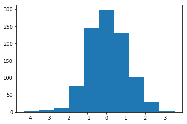

```python
from matplotlib import pyplot as plt
from scipy.stats import norm
# bez tego polecenia nie zobaczymy wykresów, dostępne są inne niż inline opcje - odsyłam do dokumentacji
%matplotlib inline

plt.hist(norm.rvs(size = 1000)); # losujemy 1000 wartości z rozkładu normalnego i rysujemy ich histogram
```